# The Association Between Emotion Regulation Strategies and Depressive Symptoms among Adolescent Girls

Author

Xinyu (Lily) Wang, Sophie Hartford, Everett Mahaffy

# Abstract

Adolescence is a developmental period marked by heightened emotional reactivity and increasing vulnerability to depression, particularly among girls. Emotion regulation (ER) strategies such as cognitive reappraisal and expressive suppression are known correlates of mental health in older adolescents and adults. Yet, less is known about how these strategies relate to depressive symptoms during early adolescence. The present study examined associations between ER strategies and depressive symptoms in a sample of 174 adolescent girls aged 10-13 from the Transitions in Adolescent Girls (TAG) study. Linear regression models showed that greater use of cognitive reappraisal was associated with lower depressive symptoms, whereas greater use of expressive suppression was associated with higher depressive symptoms. These effects remained significant in a multiple regression model including both ER strategies. Exploratory moderation analyses revealed that age did not moderate the association between reappraisal and depressive symptoms or suppression and depression. Findings highlight early adolescence as a critical window for promoting adaptive ER skills and reducing depression risk, underscoring the importance of early prevention and intervention efforts.

*Keywords: Adolescent depression, emotion regulation, developmental timing*

# Introduction

## Depression in Adolescent Girls

Major depressive disorder (MDD) and depressive symptoms are among the most significant mental health concerns affecting adolescents (Benton et al., 2021). Measured in Years Lived with Disability (YLD), depression is one of the leading causes of disability worldwide, contributing significantly to the global burden of disease (Reddy, 2010). Institute for Health Metrics and Evaluation (2019) reported that depression had become the second leading cause of disability, with 605.67 YLDs per 100,000 in 2019.

The issue has become critical among adolescents. According to the National Institute of Mental Health (2021), the prevalence of MDD among adolescents reached 5 million, accounting for 20.1% of the U.S. population aged 12-17. The prevalence was higher among adolescent females (29.2%) compared to adolescent males (11.5%). MDD is significantly associated with a range of developmental outcomes, such as educational attainment (Breslau et al., 2008, 2011; Lee et al., 2009), early childbearing (Marcus & Heringhausen, 2009), and occupational functioning and age at marriage (Fakhari et al., 2020), implying that MDD is associated with adverse health outcomes and long-term impairment, particularly when it begins in adolescence. Given its high prevalence and far-reaching consequences, it is critical to identify the mechanisms, as well as the risk and resilience factors, that contribute to the onset and progression of depressive symptoms in adolescence.

## Emotion Regulation Strategies

Although adolescents are, on average, more often happy than unhappy (Larson et al., 2002; McLaughlin et al., 2015), several critical emotional changes occur during adolescence (Coe-Odess et al., 2019). Adolescents show greater variability in daily affect (Larson et al., 2002; Maciejewski et al., 2017), higher levels of negative affect, and lower levels of positive affect compared to younger children (Abitante et al., 2022; Griffith et al., 2021). These changes in affect likely place increased demands on adolescents’ ability to manage such emotions, underscoring the importance of effective ER skills in adolescence. These shifts appear to occur between early and middle adolescence, highlighting a potential sensitive period for intervention.

ER strategies differ markedly in their effectiveness. Strategies such as reappraisal, acceptance, and distraction reliably reduce negative affect and enhance positive affect (Boemo et al., 2022; Wante et al., 2018), whereas rumination, expressive suppression, and worry are typically linked to increases in negative affect (Boemo et al., 2022). Among these, cognitive reappraisal and expressive suppression are two of the most widely studied strategies, and both have been strongly implicated in mental health outcomes. Cognitive reappraisal involves reframing an emotional stimulus and redirecting attention to the emotional scenario to change its emotional impact (Gross, 2015; Gross & John, 2003). While expressive suppression involves the inhibition of overt expression of emotion (Gross, 2015; Gross & John, 2003).

## Emotion Regulation and Mental Health

ER has been identified as a transdiagnostic factor in both internalizing and externalizing psychopathology during adolescence (Aldao et al., 2016; Joormann & Stanton, 2016; Özlem Schäfer et al., 2017). Cognitive emotion regulation strategies (e.g., cognitive reappraisal) appear to be particularly salient predictors of later mental health in adolescence (Brinke et al., 2021; Zagaria et al., 2023). Thus, ER has been proposed as a key early identification factor for detecting mental health concerns (Murray et al., 2024). Difficulties with ER, like emotion maladaptation, are strong predictors and early signs of depression, especially in youth (Paulus et al., 2021). However, the majority of work investigating the relation between ER and depression has focused on adult or late-adolescent populations. Given that early adolescence has been proposed as a particularly pivotal period (Silvers, 2022; Uhlhaas et al., 2023), the present study sought to examine these associations in early adolescence, focusing on girls given their elevated risk of developing depression.

## Aims and Hypotheses

We aimed to examine the association between emotion regulation strategies (reappraisal and suppression) and depressive symptoms among young adolescent girls, and we predicted 1). higher reappraisal usage will be associated with lower depressive symptoms, and 2). higher suppression usage will be associated with higher depressive symptoms. Additionally, exploratory analyses examined whether each ER strategy remained associated with depressive symptoms when adjusting for the other strategy, and whether age moderated these associations.

# Method

## Participants

The present study uses baseline data from the Transitions in Adolescent Girls (TAG) study, a longitudinal project examining the developmental trajectories of pubertal, neurological, and social processes as mechanisms underlying the emergence of mental illness in female adolescents (Barendse et al., 2019). A total of 174 adolescent girls were recruited from the local community in Lane County, Oregon, USA, primarily through letters sent by schools to all families with children registered as female students. The inclusion criteria required participants to be 10-13 years old at enrollment, fluent in English, and have normal or corrected-to-normal vision. Exclusion criteria included current use of psychotropic medication, MRI contraindications (e.g., claustrophobia, presence of ferromagnetic material in the body), suspected or confirmed pregnancy, and diagnoses of a developmental disability, psychotic disorder, or behavioral disorder (including autism). Parents or legal guardians provided informed consent, and adolescents provided assent before participation.

### Figure 1. Plot of TAG Participants

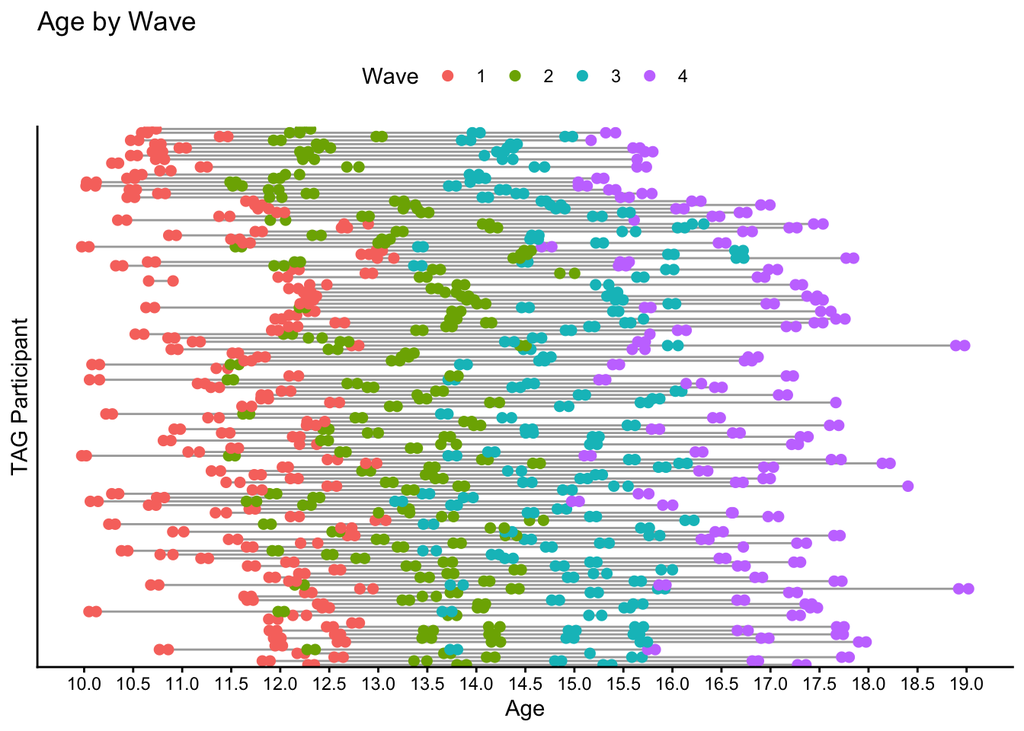

## Measures

### Emotion Regulation Strategies

Emotion regulation strategies were measured using the Emotion Regulation Questionnaire (ERQ) (Gross & John, 2003). The ERQ contains 10 items that assess individuals’ use of emotion regulation, with six items assessing cognitive reappraisal and four assessing expressive suppression. Each item is rated on a 7-point Likert scale, ranging from 1 (“strongly disagree”) to 7 (“strongly agree”). The present analyses treat each scale (reappraisal and suppression) separately.

## Analytic Plan

All analyses were conducted in *R* (R Core Team, 2025). Data preparation utilized the following packages: *tidyverse* (Wickham et al., 2019), *here* (Müller, 2020), *readxl* (Wickham & Bryan, 2025), *janitor* (Firke, 2024), *modelsummary* (Arel-Bundock, 2022), *performance* (Lüdecke et al., 2021), and *flextable* (Gohel & Skintzos, 2025). For primary research questions 1 and 2, we estimated linear regression models to quantify the relation between the use of each ER strategy and depressive symptoms. For exploratory research question 1, we estimated a linear multiple regression model, which included both reappraisal and suppression as predictors. For exploratory research questions 2 and 3, we included an interaction term to explore adolescent age as a potential moderator. All *p*-values were evaluated at *α* = .05.

# Results

## Descriptive Statistics

Sample descriptive statistics are reported in Table 1. Participants were young adolescent girls with a mean age of 11.6 years (SD = 0.8, range = 10–13.1). On average, adolescents reported moderate use of emotion regulation strategies. Mean reappraisal scores were 27.4 (SD = 6.6, range = 6–41), and mean suppression scores were 13.7 (SD = 5.2, range = 5–28). Depressive symptoms were generally low to moderate, with a mean score of 12.8 (SD = 10.4, range = 0–50).

### Table 1. Sample Summary Statistics

Unique

Missing Pct.

Mean

SD

Min

Median

Max

Histogram

Reappraisal

31

2

27.4

6.6

6.0

28.0

41.0

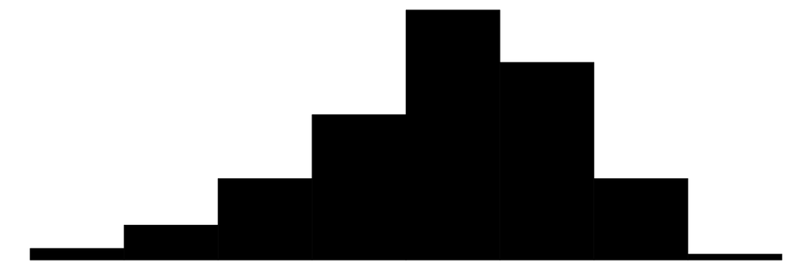

Suppression

24

2

13.7

5.2

5.0

13.0

28.0

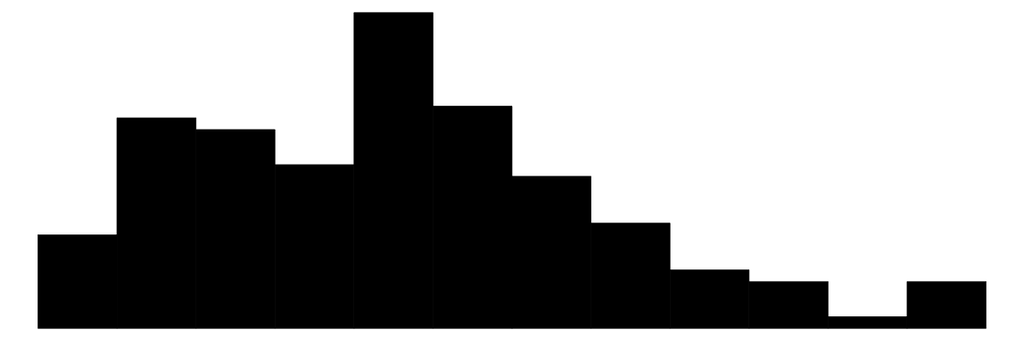

Depression

49

5

12.8

10.3

0.0

9.5

50.0

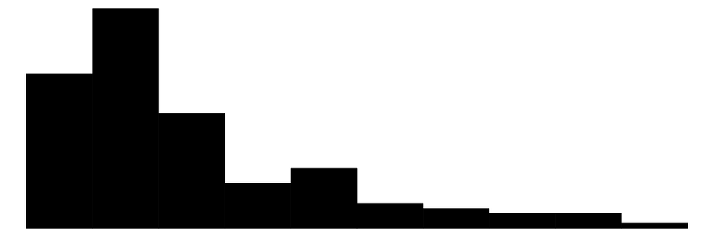

Age

141

1

11.6

0.8

10.0

11.7

13.1

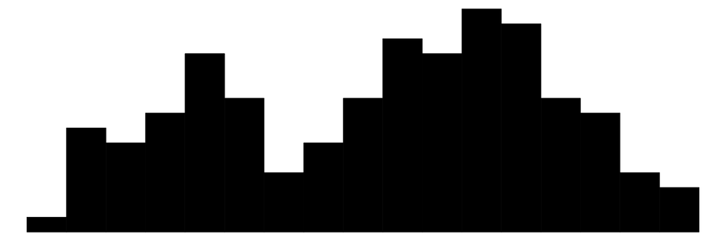

Ethnicity

N

%

a. Black/ African American

8

0.7

b. Hispanic/ Latino/ Chicano

48

4.2

c. Native American or Native Alaskan

8

0.7

d. White / Caucasian

720

63.4

e. Asian

16

1.4

g. Multi-racial

248

21.8

h. Other

16

1.4

j. Decline to respond

8

0.7

NA

64

5.6

## Emotion Regulation and Depression

The association between expressive suppression and depression is shown in Figure 2. A linear regression was conducted to assess the relation between expressive suppression and depressive symptoms. The model was significant, *F*(1, 130) = 16.78, *p* < .001, accounting for about 11% of the variance in depressive symptoms (*R*² = 0.11). Expressive suppression significantly predicted depressive symptoms, with higher suppression associated with higher symptom scores, *b* = 0.64, *SE* = 0.16, *t* = 4.1, *p* < .001.

### Table 2. Model Summary for RQ1 and RQ2

|  | Reappraisal | Suppression |
| --- | --- | --- |
| Intercept | 22.805*** | 3.864+ |
|  | (3.719) | (2.277) |
| Reappraisal (ERQ) | -0.362** |  |
|  | (0.132) |  |
| Suppression (ERQ) |  | 0.645*** |
|  |  | (0.157) |
| Num.Obs. | 132 | 132 |
| R2 | 0.055 | 0.114 |
| R2 Adj. | 0.047 | 0.108 |
| AIC | 991.6 | 970.1 |
| BIC | 1000.3 | 978.8 |
| Log.Lik. | -492.802 | -482.065 |
| F | 7.512 |  |
| RMSE | 10.12 | 9.33 |

+ p < 0.1, * p < 0.05, ** p < 0.01, *** p < 0.001

### Figure 1

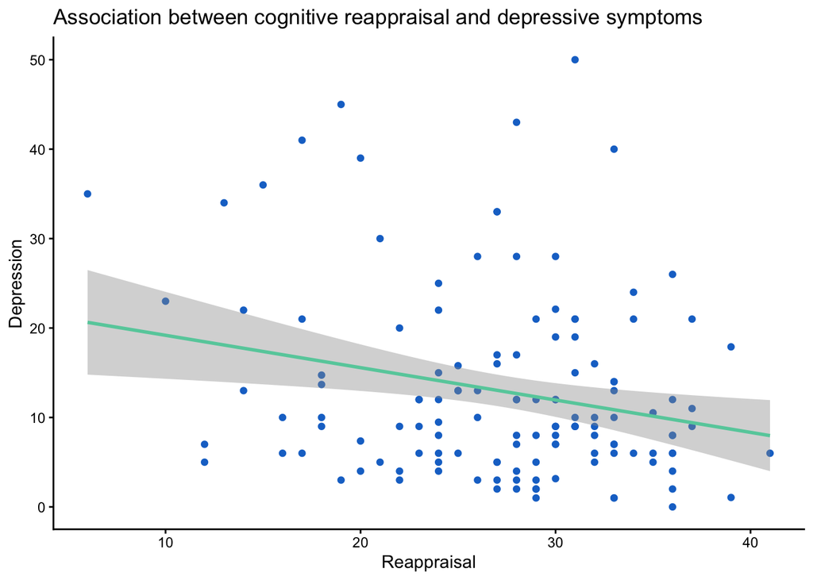

### Figure 2

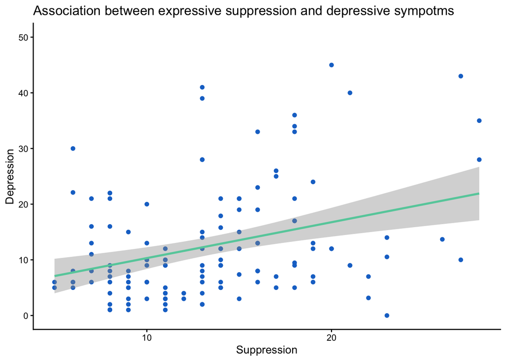

## Exploratory Analysis

### Table 3. Model Summaries for Multiple Regression and Interaction Models

|  | Suppression + Reappraisal | Reappraisal × Age Interaction | Suppression × Age Interaction |
| --- | --- | --- | --- |
| Intercept | 13.733** | 40.986 | 2.701 |
|  | (4.240) | (52.786) | (31.659) |
| Reappraisal (ERQ) | -0.332** | -1.688 |  |
|  | (0.122) | (1.847) |  |
| Suppression (ERQ) | 0.592*** |  | 0.053 |
|  | (0.156) |  | (2.131) |
| Reappraisal x Age |  | 0.116 |  |
|  |  | (0.161) |  |
| Suppression x Age |  |  | 0.049 |
|  |  |  | (0.182) |
| Num.Obs. | 129 | 132 | 132 |
| R2 | 0.164 | 0.075 | 0.119 |
| R2 Adj. | 0.151 | 0.054 | 0.099 |
| AIC | 945.0 | 992.7 | 973.4 |
| BIC | 956.5 | 1007.1 | 987.8 |
| Log.Lik. | -468.520 | -491.348 | -481.683 |
| F |  | 3.471 |  |
| RMSE | 9.14 | 10.01 | 9.30 |

+ p < 0.1, * p < 0.05, ** p < 0.01, *** p < 0.001

### Figure 3

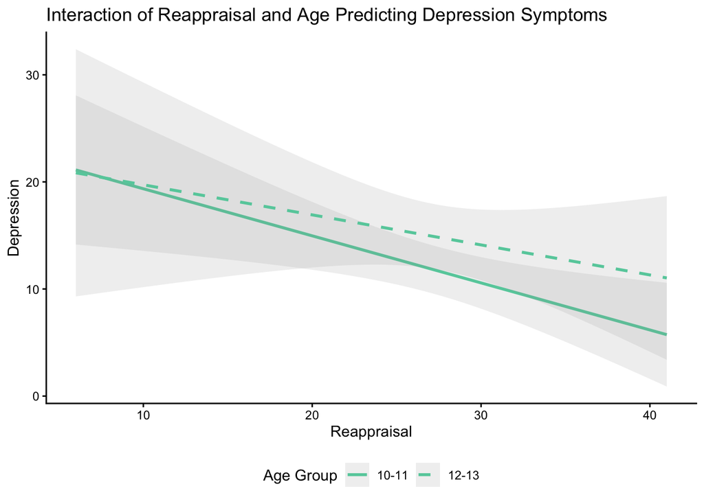

### Figure 4

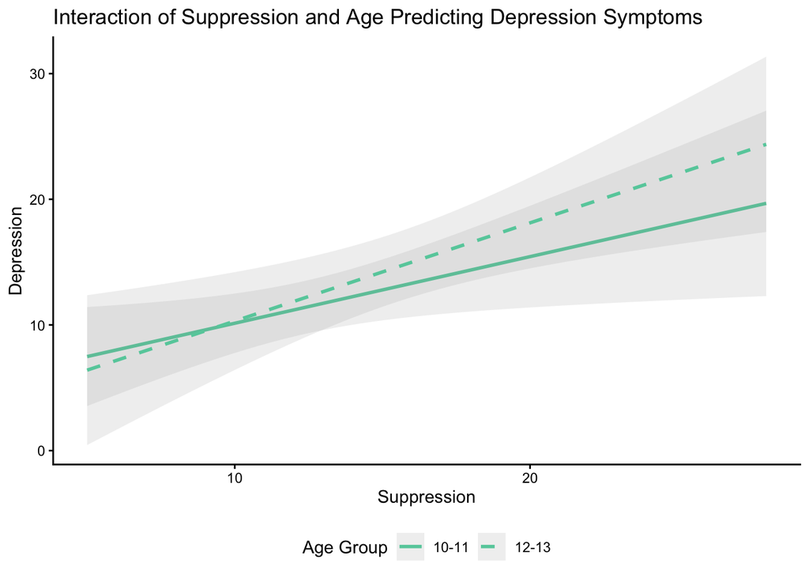

# Discussion

The present study investigated associations between two core emotion regulation (ER) strategies, cognitive reappraisal and expressive suppression, and depressive symptoms among young adolescent girls, as well as whether age moderated these associations. Across analytic approaches, results revealed that greater use of cognitive reappraisal was linked to lower depressive symptoms, whereas greater use of expressive suppression was linked to higher depressive symptoms. These findings are consistent with the broader ER literature (Aldao et al., 2010; Compas et al., 2017) and demonstrate that these patterns are already evident during early adolescence, a developmental stage characterized by heightened emotional reactivity and growing vulnerability to internalizing disorders.

## Emotion Regulation as a Salient Predictor in Early Adolescence

Our findings underscore the relevance of ER strategy use for understanding depressive symptoms at a time when girls experience disproportionately high increases in depression risk (Rohde et al., 2009). Reappraisal, a strategy involving reframing emotional situations to alter one’s emotional experience, was negatively associated with depressive symptoms, supporting its conceptualization as an adaptive and protective regulatory strategy (Dryman & Heimberg, 2018). In contrast, suppression, a strategy aimed at inhibiting outward emotional expression, was associated with higher depressive symptoms, consistent with its categorization as a maladaptive strategy linked to emotional distancing, reduced social support, and increased physiological stress responses (Ehring et al., 2010).

Importantly, these associations persisted when the two strategies were modeled together, suggesting that each contributes uniquely to depressive symptoms rather than functioning as opposite ends of a single continuum. This distinction adds nuance to our understanding of ER processes that adolescents may simultaneously engage in both adaptive and maladaptive strategies, and the balance between them may contribute meaningfully to mental health.

## Developmental Considerations and Age as a Moderator

Exploratory analyses further revealed that age did not moderate the association between reappraisal and depressive symptoms. Although reappraisal was associated with lower depressive symptoms across the full sample, this protective association appeared weaker among older adolescents; however, this result was not statistically significant. Thus, it is possible that that developmental changes in emotional, cognitive, or social processes may influence the effectiveness with which reappraisal is deployed across the early and later stages of adolescence; however, more research is needed to investigate this potential moderation effect, particularly across a larger range of adolescents. For instance, younger adolescents may benefit more from cognitive reframing strategies as they begin to encounter more complex emotional challenges. In contrast, older adolescents may increasingly rely on a broader set of regulatory skills or face social contexts that diminish the effectiveness of reappraisal. This finding is consistent with conceptual models that propose early adolescence as a sensitive period for the development of ER skills (Silvers, 2022) and underscores the importance of strengthening adaptive regulation strategies before adolescence progresses further.

Moreover, age did not moderate the association between expressive suppression and depressive symptoms. Suppression was linked to elevated depressive symptoms regardless of age. This suggests that suppression may function as a consistently maladaptive strategy across early adolescence, possibly because it interferes with emotional expression, social connectedness, and psychological flexibility in ways that are detrimental at any age during this developmental period.

## Implications for Theory, Prevention, and Intervention

These findings have several theoretical and applied implications. Theoretically, they support models positioning ER as a transdiagnostic factor in the development of internalizing symptoms (Aldao et al., 2016). They also align with neurodevelopmental models suggesting that early adolescence marks a sensitive period for the maturation of prefrontal and limbic circuitry involved in cognitive regulation of emotion (Gee, 2016). Because reappraisal relies heavily on prefrontal control processes, its benefits may be particularly meaningful when these neural systems are still maturing.

## Limitations and Future Directions

Several limitations should be considered when interpreting these findings. First, the present study relied on baseline cross-sectional data, which limits our ability to draw conclusions about directionality or causal pathways between ER and depressive symptoms. Longitudinal analyses are needed to determine whether ER strategies predict changes in depressive symptoms over time, or vice versa. Second, all variables were assessed via self-report, which may introduce shared method variance or reporting biases. Incorporating multi-method assessments, including parent-report, behavioral tasks, or physiological indicators, would help strengthen the validity of future findings. Third, although our sample was demographically representative of the geographic region, it was not highly diverse, and replication in more heterogeneous samples would improve generalizability. Finally, our models focused on two ER strategies, but adolescents use a vast repertoire of regulation behaviors; future work should examine additional strategies and consider how they interact within broader ER profiles.

## References

Abitante, G., Haraden, D. A., Pine, A., Cole, D., & Garber, J. (2022). Trajectories of positive and negative affect across adolescence: Maternal history of depression and adolescent sex as predictors. *Journal of Affective Disorders*, *315*, 96–104. https://doi.org/10.1016/j.jad.2022.07.038

Aldao, A., Gee, D. G., De Los Reyes, A., & Seager, I. (2016). Emotion regulation as a transdiagnostic factor in the development of internalizing and externalizing psychopathology: Current and future directions. *Development and Psychopathology*, *28*(4pt1), 927–946.

Aldao, A., Nolen-Hoeksema, S., & Schweizer, S. (2010). Emotion-regulation strategies across psychopathology: A meta-analytic review. *Clinical Psychology Review*, *30*(2), 217–237. https://doi.org/10.1016/j.cpr.2009.11.004

Arel-Bundock, V. (2022). modelsummary: Data and model summaries in R. *Journal of Statistical Software*, *103*(1), 1–23. https://doi.org/10.18637/jss.v103.i01

Barendse, M. E. A., Vijayakumar, N., Byrne, M. L., Flannery, J. E., Cheng, T. W., Flournoy, J. C., Nelson, B. W., Cosme, D., Mobasser, A., Chavez, S. J., Hval, L., Brady, B., Nadel, H., Helzer, A., Shirtcliff, E. A., Allen, N. B., & Pfeifer, J. H. (2019). Study Protocol: Transitions in Adolescent Girls (TAG). *Frontiers in Psychiatry*, *10*, 1018. https://doi.org/10.3389/fpsyt.2019.01018

Benton, T. D., Boyd, R. C., & Njoroge, W. F. (2021). Addressing the global crisis of child and adolescent mental health. *JAMA Pediatrics*, *175*(11), 1108–1110.

Boemo, T., Nieto, I., Vazquez, C., & Sanchez-Lopez, A. (2022). Relations between emotion regulation strategies and affect in daily life: A systematic review and meta-analysis of studies using ecological momentary assessments. *Neuroscience & Biobehavioral Reviews*, *139*, 104747. https://doi.org/10.1016/j.neubiorev.2022.104747

Breslau, J., Lane, M., Sampson, N., & Kessler, R. C. (2008). Mental disorders and subsequent educational attainment in a US national sample. *Journal of Psychiatric Research*, *42*(9), 708–716.

Breslau, J., Miller, E., Chung, W.-J. J., & Schweitzer, J. B. (2011). Childhood and adolescent onset psychiatric disorders, substance use, and failure to graduate high school on time. *Journal of Psychiatric Research*, *45*(3), 295–301.

Brinke, L. W. te, Menting, A. T. A., Schuiringa, H. D., Zeman, J., & Deković, M. (2021). The structure of emotion regulation strategies in adolescence: Differential links to internalizing and externalizing problems. *Social Development*, *30*(2), 536–553. https://doi.org/10.1111/sode.12496

Coe-Odess, S. J., Narr, R. K., & Allen, J. P. (2019). *Emergent Emotions in Adolescence* (V. LoBue, K. Pérez-Edgar, & K. A. Buss, Eds.; pp. 595–625). Springer International Publishing. https://doi.org/10.1007/978-3-030-17332-6_23

Compas, B. E., Jaser, S. S., Bettis, A. H., Watson, K. H., Gruhn, M. A., Dunbar, J. P., Williams, E., & Thigpen, J. C. (2017). Coping, emotion regulation, and psychopathology in childhood and adolescence: A meta-analysis and narrative review. *Psychological Bulletin*, *143*(9), 939–991. https://doi.org/10.1037/bul0000110

Dryman, M. T., & Heimberg, R. G. (2018). Emotion regulation in social anxiety and depression: A systematic review of expressive suppression and cognitive reappraisal. *Clinical Psychology Review*, *65*, 17–42.

Ehring, T., Tuschen-Caffier, B., Schnülle, J., Fischer, S., & Gross, J. J. (2010). Emotion regulation and vulnerability to depression: Spontaneous versus instructed use of emotion suppression and reappraisal. *Emotion*, *10*(4), 563.

Fakhari, A., Farahbakhsh, M., Azizi, H., Esmaeili, E. D., Mirzapour, M., Rahimi, V. A., Hashemi, L., & Gaffarifam, S. (2020). Early marriage and negative life events affect on depression in young adults and adolescents. *Archives of Iranian Medicine*, *23*(2), 90–98.

Firke, S. (2024). *Janitor: Simple tools for examining and cleaning dirty data*. https://doi.org/10.32614/CRAN.package.janitor

Gee, D. G. (2016). Sensitive periods of emotion regulation: Influences of parental care on frontoamygdala circuitry and plasticity. *New Directions for Child and Adolescent Development*, *2016*(153), 87–110.

Gohel, D., & Skintzos, P. (2025). *Flextable: Functions for tabular reporting*. https://doi.org/10.32614/CRAN.package.flextable

Griffith, J. M., Clark, H. M., Haraden, D. A., Young, J. F., & Hankin, B. L. (2021). Affective development from middle childhood to late adolescence: trajectories of mean-level change in negative and positive affect. *Journal of Youth and Adolescence*, *50*(8), 1550–1563. https://doi.org/10.1007/s10964-021-01425-z

Gross, J. J. (2015). Emotion regulation: current status and future prospects. *Psychological Inquiry*, *26*(1), 1–26. https://doi.org/10.1080/1047840X.2014.940781

Gross, J. J., & John, O. P. (2003). Individual differences in two emotion regulation processes: Implications for affect, relationships, and well-being. *Journal of Personality and Social Psychology*, *85*(2), 348–362. https://doi.org/10.1037/0022-3514.85.2.348

Institute for Health Metrics and Evaluation. (2019). *Global health data exchange (GHDx): Depressive disorders—years lived with disability*. IHME. https://ghdx.healthdata.org/

Joormann, J., & Stanton, C. H. (2016). Examining emotion regulation in depression: A review and future directions. *Behaviour Research and Therapy*, *86*, 35–49. https://doi.org/10.1016/j.brat.2016.07.007

Larson, R. W., Moneta, G., Richards, M. H., & Wilson, S. (2002). Continuity, stability, and change in daily emotional experience across adolescence. *Child Development*, *73*(4), 1151–1165. https://doi.org/10.1111/1467-8624.00464

Lee, S., Tsang, A., Breslau, J., Aguilar-Gaxiola, S., Angermeyer, M., Borges, G., Bromet, E., Bruffaerts, R., De Girolamo, G., Fayyad, J., et al. (2009). Mental disorders and termination of education in high-income and low-and middle-income countries: Epidemiological study. *The British Journal of Psychiatry*, *194*(5), 411–417.

Lüdecke, D., Ben-Shachar, M. S., Patil, I., Waggoner, P., & Makowski, D. (2021). performance: An R package for assessment, comparison and testing of statistical models. *Journal of Open Source Software*, *6*(60), 3139. https://doi.org/10.21105/joss.03139

Maciejewski, D. F., Lier, P. A. C. van, Branje, S. J. T., Meeus, W. H. J., & Koot, H. M. (2017). A daily diary study on adolescent emotional experiences: Measurement invariance and developmental trajectories. *Psychological Assessment*, *29*(1), 35–49. https://doi.org/10.1037/pas0000312

Marcus, S. M., & Heringhausen, J. E. (2009). Depression in childbearing women: When depression complicates pregnancy. *Primary Care: Clinics in Office Practice*, *36*(1), 151–165.

McLaughlin, K. A., Garrad, M. C., & Somerville, L. H. (2015). What develops during emotional development? A component process approach to identifying sources of psychopathology risk in adolescence. *Dialogues in Clinical Neuroscience*, *17*(4), 403–410. https://doi.org/10.31887/DCNS.2015.17.4/kmclaughlin

Müller, K. (2020). *Here: A simpler way to find your files*. https://doi.org/10.32614/CRAN.package.here

Murray, A. L., Russell, A., & Calderón Alfaro, F. A. (2024). Early emotion regulation developmental trajectories and ADHD, internalizing, and conduct problems symptoms in childhood. *Development and Psychopathology*, 1–8. https://doi.org/10.1017/S0954579424001263

National Institute of Mental Health. (2021). *Major depression*. U.S. Department of Health; Human Services, National Institutes of Health; https://www.nimh.nih.gov/health/statistics/major-depression.

Özlem Schäfer, J., Naumann, E., Holmes, E. A., Tuschen-Caffier, B., & Samson, A. C. (2017). Emotion regulation strategies in depressive and anxiety symptoms in youth: a meta-analytic review. *Journal of Youth and Adolescence*, *46*(2), 261–276. https://doi.org/10.1007/s10964-016-0585-0

Paulus, F. W., Ohmann, S., Möhler, E., Plener, P., & Popow, C. (2021). Emotional dysregulation in children and adolescents with psychiatric disorders. A narrative review. *Frontiers in Psychiatry*, *12*, 628252.

R Core Team. (2025). *R: A language and environment for statistical computing*. R Foundation for Statistical Computing. https://www.R-project.org/

Reddy, M. (2010). Depression: The disorder and the burden. In *Indian journal of psychological medicine* (1; Vol. 32, pp. 1–2). SAGE Publications Sage India: New Delhi, India.

Rohde, P., Beevers, C. G., Stice, E., & O’Neil, K. (2009). Major and minor depression in female adolescents: Onset, course, symptom presentation, and demographic associations. *Journal of Clinical Psychology*, *65*(12), 1339–1349.

Silvers, J. A. (2022). Adolescence as a pivotal period for emotion regulation development. *Current Opinion in Psychology*, *44*, 258–263. https://doi.org/10.1016/j.copsyc.2021.09.023

Uhlhaas, P. J., Davey, C. G., Mehta, U. M., Shah, J., Torous, J., Allen, N. B., Avenevoli, S., Bella-Awusah, T., Chanen, A., Chen, E. Y. H., Correll, C. U., Do, K. Q., Fisher, H. L., Frangou, S., Hickie, I. B., Keshavan, M. S., Konrad, K., Lee, F. S., Liu, C. H., … Wood, S. J. (2023). Towards a youth mental health paradigm: A perspective and roadmap. *Molecular Psychiatry*, *28*(8), 3171–3181. https://doi.org/10.1038/s41380-023-02202-z

Wante, L., Van Beveren, M.-L., Theuwis, L., & Braet, C. (2018). The effects of emotion regulation strategies on positive and negative affect in early adolescents. *Cognition and Emotion*, *32*(5), 988–1002. https://doi.org/10.1080/02699931.2017.1374242

Weissman, M. M., Orvaschel, H., & Padian, N. (1980). Children’s symptom and social functioning self-report scales. Comparison of mothers’ and children’s reports. *The Journal of Nervous and Mental Disease*, *168*(12), 736–740. https://doi.org/10.1097/00005053-198012000-00005

Wickham, H., Averick, M., Bryan, J., Chang, W., McGowan, L. D., François, R., Grolemund, G., Hayes, A., Henry, L., Hester, J., Kuhn, M., Pedersen, T. L., Miller, E., Bache, S. M., Müller, K., Ooms, J., Robinson, D., Seidel, D. P., Spinu, V., … Yutani, H. (2019). Welcome to the tidyverse. *Journal of Open Source Software*, *4*(43), 1686. https://doi.org/10.21105/joss.01686

Wickham, H., & Bryan, J. (2025). *Readxl: Read excel files*. https://doi.org/10.32614/CRAN.package.readxl

Zagaria, A., Vacca, M., Cerolini, S., Terrasi, M., Bacaro, V., Ballesio, A., Baglioni, C., Spinhoven, P., & Lombardo, C. (2023). Differential associations of cognitive emotion regulation strategies with depression, anxiety, and insomnia in adolescence and early adulthood. *International Journal of Environmental Research and Public Health*, *20*(10), 5857. https://doi.org/10.3390/ijerph20105857